# HSC Survey Results

# German Bank Survey # 1 Results from 09/08/2026

## Survey Details

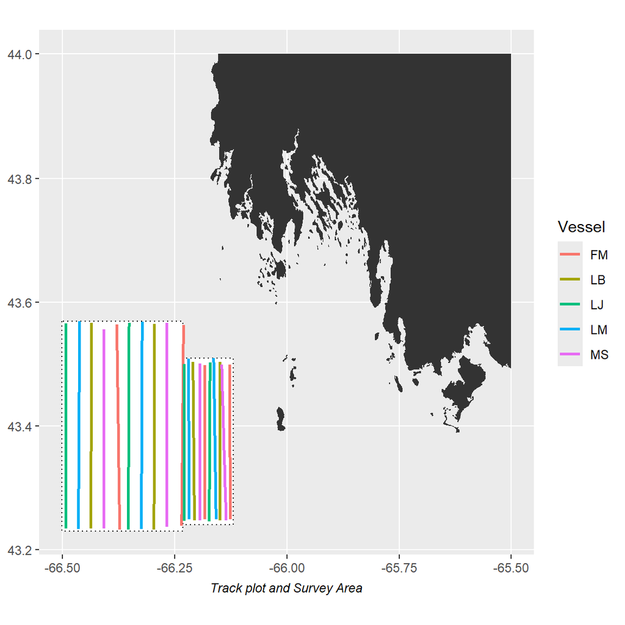

All vessels ran two transects in the German Bank box and two transect in the Seal Island Box.

There was a plankton tow and replicate conducted and CTD cast by Fundy Monarch.

No tags were applied during this survey.

Samples were obtained for target strength estimation.

### Acoustic Equipment

Each vessel was equipped with a Simrad ES38-18/200-18C combi (2-in-1) transducer prior to the survey that contains a 38kHz split beam and 200 kHz single beam transducer. Data was logged to the computer hard-drive for post-processing. All participating boats were calibrated on 38kHz before the survey.

## Survey Results

### Main Results

The results are subject to change as DFO will re-evaluate data editing, area estimation and apply a target strength.

**Preliminary biomass prediction for German Bank using standardized parallel transects is 51,965mt. The preliminary biomass estimate for Seal Island is 7,023mt.**

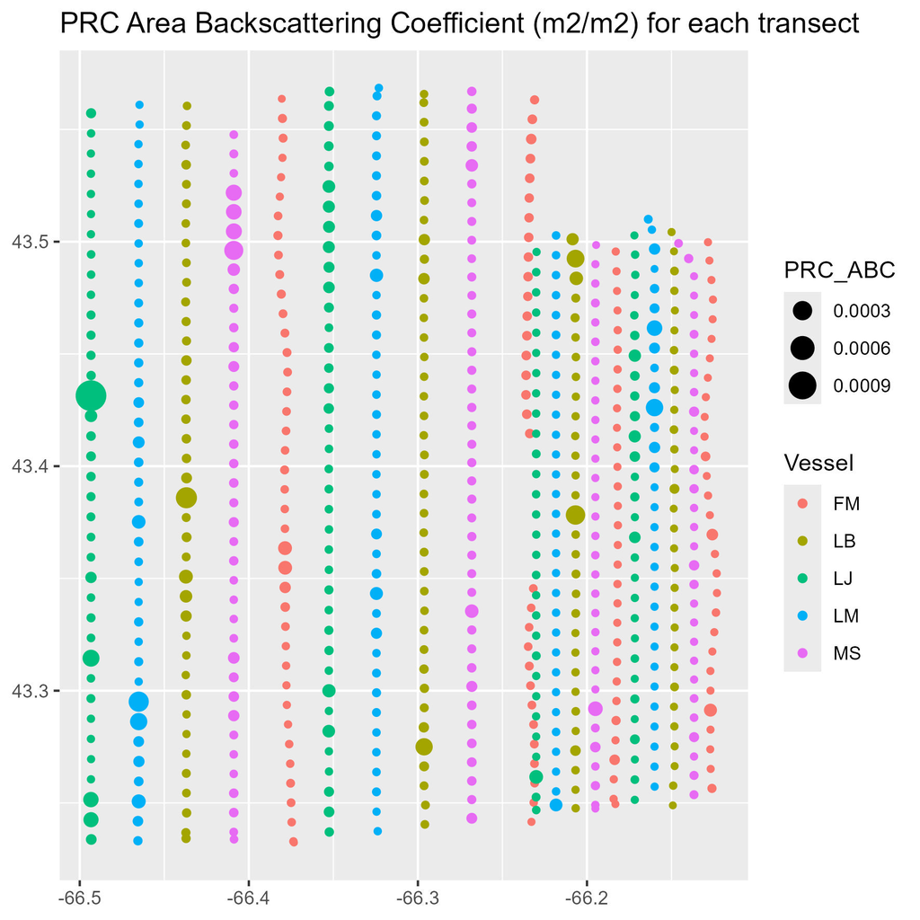

### Transect Details

Table 1: Transect Details

| Vessel | Transect # | Date/Time Start | Date/Time End | Start Lon | Start Lat | End Lon | End Lat | Location | Distance (km) | Speed |
| --- | --- | --- | --- | --- | --- | --- | --- | --- | --- | --- |
| FM | T01 | 2026-08-09 21:32:01 | 2026-08-09 23:52:47 | -66.380 | 43.564 | -66.373 | 43.232 | GB | 38.17 | 8.78 |
| FM | T02 | 2026-08-10 00:26:47 | 2026-08-10 02:46:42 | -66.235 | 43.239 | -66.231 | 43.563 | GB | 37.39 | 8.66 |
| FM | T03 | 2026-08-10 03:10:29 | 2026-08-10 04:57:01 | -66.184 | 43.499 | -66.183 | 43.249 | GB | 28.64 | 8.71 |
| FM | T04 | 2026-08-10 05:14:13 | 2026-08-10 07:00:00 | -66.127 | 43.249 | -66.128 | 43.500 | GB | 28.82 | 8.83 |
| LB | T01 | 2026-08-09 20:08:39 | 2026-08-09 22:34:09 | -66.437 | 43.567 | -66.437 | 43.234 | GB | 38.07 | 8.48 |
| LB | T02 | 2026-08-09 23:11:46 | 2026-08-10 01:58:14 | -66.297 | 43.233 | -66.296 | 43.566 | GB | 38.37 | 7.47 |
| LB | T03 | 2026-08-10 02:30:21 | 2026-08-10 04:18:17 | -66.210 | 43.504 | -66.207 | 43.248 | GB | 29.28 | 8.79 |
| LB | T04 | 2026-08-10 04:38:18 | 2026-08-10 06:24:30 | -66.149 | 43.247 | -66.150 | 43.504 | GB | 29.22 | 8.91 |
| LJ | T01 | 2026-08-09 20:36:54 | 2026-08-09 23:00:47 | -66.493 | 43.566 | -66.493 | 43.234 | GB | 36.97 | 8.32 |
| LJ | T02 | 2026-08-09 23:34:32 | 2026-08-10 02:02:01 | -66.354 | 43.232 | -66.352 | 43.567 | GB | 37.27 | 8.19 |
| LJ | T03 | 2026-08-10 02:38:00 | 2026-08-10 04:28:47 | -66.229 | 43.501 | -66.230 | 43.247 | GB | 28.26 | 8.26 |
| LJ | T04 | 2026-08-10 04:45:20 | 2026-08-10 06:33:05 | -66.174 | 43.246 | -66.172 | 43.503 | GB | 28.70 | 8.63 |
| LM | T01 | 2026-08-09 20:30:10 | 2026-08-09 22:56:28 | -66.463 | 43.569 | -66.465 | 43.233 | GB | 38.03 | 8.42 |
| LM | T02 | 2026-08-09 23:27:01 | 2026-08-10 01:54:08 | -66.325 | 43.233 | -66.323 | 43.568 | GB | 37.96 | 8.36 |
| LM | T03 | 2026-08-10 02:23:02 | 2026-08-10 04:15:01 | -66.220 | 43.509 | -66.218 | 43.249 | GB | 29.45 | 8.52 |
| LM | T04 | 2026-08-10 04:35:07 | 2026-08-10 06:26:23 | -66.158 | 43.249 | -66.164 | 43.510 | GB | 29.52 | 8.59 |
| MS | T01 | 2026-08-09 21:31:19 | 2026-08-09 23:45:59 | -66.409 | 43.556 | -66.409 | 43.234 | GB | 37.38 | 8.99 |
| MS | T02 | 2026-08-10 00:21:42 | 2026-08-10 02:52:57 | -66.268 | 43.237 | -66.268 | 43.567 | GB | 39.68 | 8.50 |
| MS | T03 | 2026-08-10 03:21:07 | 2026-08-10 05:11:35 | -66.194 | 43.501 | -66.195 | 43.247 | GB | 29.54 | 8.66 |
| MS | T04 | 2026-08-10 05:29:53 | 2026-08-10 07:12:56 | -66.136 | 43.247 | -66.146 | 43.499 | GB | 29.71 | 9.34 |

### Survey Summary

Table 2: Acoustic Survey Results

| Vessel | Transect No. | Target Strength (db/kg) | Mean Sa (/m2) | Biomass Density (kg/m2) |
| --- | --- | --- | --- | --- |
| LJ | T01 | -35.5 | -43.035 | 0.176 |
| MS | T01 | -35.5 | -45.437 | 0.101 |
| LM | T01 | -35.5 | -46.073 | 0.088 |
| LB | T03 | -35.5 | -46.356 | 0.082 |
| LB | T01 | -35.5 | -47.147 | 0.068 |
| LM | T04 | -35.5 | -47.581 | 0.062 |
| LJ | T02 | -35.5 | -48.301 | 0.052 |
| LB | T02 | -35.5 | -50.027 | 0.035 |
| MS | T02 | -35.5 | -50.116 | 0.035 |
| LM | T02 | -35.5 | -50.822 | 0.029 |
| LJ | T04 | -35.5 | -51.146 | 0.027 |
| FM | T01 | -35.5 | -51.277 | 0.026 |
| FM | T02 | -35.5 | -52.162 | 0.022 |
| MS | T03 | -35.5 | -52.486 | 0.020 |
| LJ | T03 | -35.5 | -53.540 | 0.016 |
| FM | T04 | -35.5 | -53.714 | 0.015 |
| MS | T04 | -35.5 | -54.743 | 0.012 |
| LM | T03 | -35.5 | -55.022 | 0.011 |
| FM | T03 | -35.5 | -57.981 | 0.006 |
| LB | T04 | -35.5 | -58.888 | 0.005 |

Note:  
Transects are listed from greatest to least backscatter.

Table 3: Survey Summary Table

| Layer | Target Strength | Area (km2) | Mean Sa | Density (kg/m2) | Biomass (tons) | Percent Area | Percent Biomass | Standard Error (tons) | Standard Error (%) |
| --- | --- | --- | --- | --- | --- | --- | --- | --- | --- |
| German Bank | -35.5 | 826 | -47.5127 | 0.0634 | 51,965.016 | 75.1 | 88.1 | 12,571.05 | 24.19 |
| Seal Island | -35.5 | 274 | -51.4123 | 0.0255 | 7,023.005 | 24.9 | 11.9 | 2,235.62 | 31.83 |

### Greatest Biomass Densities

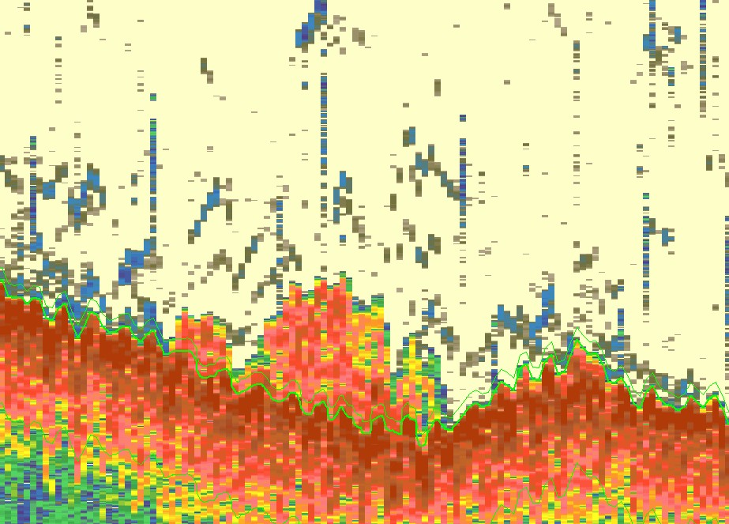

A snip from the transect with the greatest biomass density (kg/m2)

The single point with the largest biomass density (kg/m2) was recorded by **LJ**, at the following location:

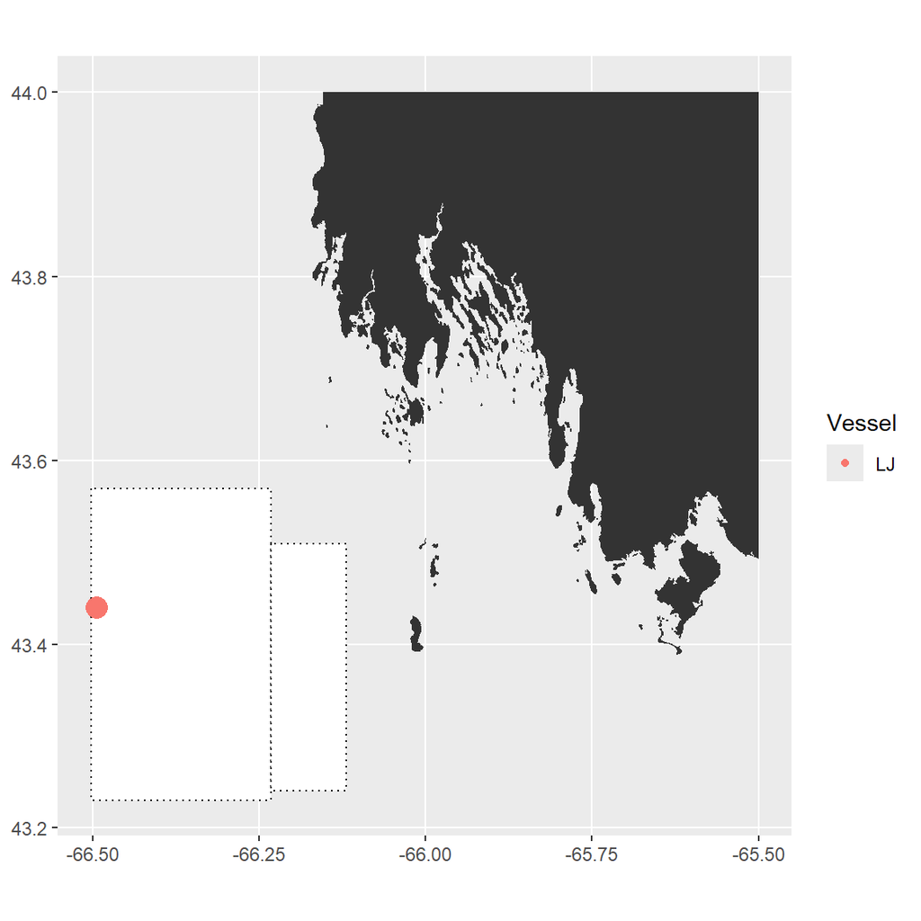

The transect with the greatest average biomass density (kg/m2) was recorded by **LJ**, at the following location:

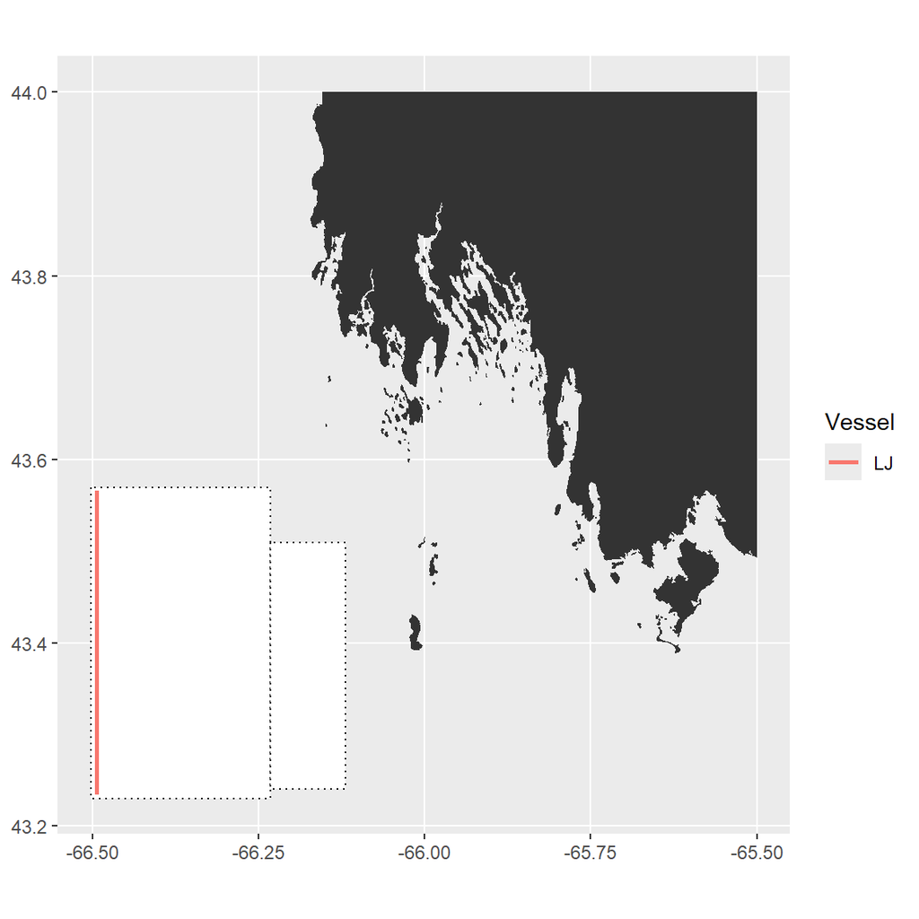

### Annual Summaries

This table does not include the biomass from adhoc surveys.

Table 4: Annual Comparison Table

| Ground | Survey Number | Current Year Survey Date | Current Year HSC Estimate | Current Year HSC Turnover Adjusted | Previous Year Survey Date | Previous Year HSC Estimate | Previous Year HSC Turnover Adjusted | Previous Year DFO Estimate | Previous Year DFO Turnover Adjusted |
| --- | --- | --- | --- | --- | --- | --- | --- | --- | --- |
| German Bank | 1 | 2026-08-09 | 51,965.016 | NA | 2025-08-04 | 6,194 | 6,194 | NA | NA |
| Seal Island | 1 | 2026-08-09 | 7,023.005 | NA | 2025-08-04 | 1,160 | NA | NA | NA |
| German Bank | 2 | NA | NA | NA | 2025-08-18 | 35,008 | 32,592 | NA | NA |
| Seal Island | 2 | NA | NA | NA | 2025-08-18 | 6,220 | NA | NA | NA |
| German Bank | 3 | NA | NA | NA | 2025-08-31 | 30,892 | 21,986 | NA | NA |
| Seal Island | 3 | NA | NA | NA | 2025-08-31 | 6,500 | NA | NA | NA |
| German Bank | 4 | NA | NA | NA | 2025-09-14 | 15,323 | 7,753 | NA | NA |
| Seal Island | 4 | NA | NA | NA | 2025-09-14 | 18,112 | NA | NA | NA |
| German Bank | 5 | NA | NA | NA | 2025-09-28 | 6,754 | 2,138 | NA | NA |
| Seal Island | 5 | NA | NA | NA | 2025-09-28 | 5,048 | NA | NA | NA |
| German Bank | 6 | NA | NA | NA | 2025-10-14 | 8,611 | 7,291 | NA | NA |
| Seal Island | 6 | NA | NA | NA | 2025-10-14 | 10,346 | NA | NA | NA |
| German Bank | 7 | NA | NA | NA | 2025-10-26 | 20,039 | 17,877 | NA | NA |
| Seal Island | 7 | NA | NA | NA | 2025-10-26 | 3,433 | NA | NA | NA |

Table 5: Annual Summary Table

| Year | Ground | HSC Estimate | HSC Turnover Adjusted | DFO Estimate | DFO Turnover Adjusted |
| --- | --- | --- | --- | --- | --- |
| 2025 | German Bank | 122,821.000 | 95,831 | NA | NA |
| 2025 | Seal Island | 50,819.000 | NA | NA | NA |
| 2026 | German Bank | 51,965.016 | NA | NA | NA |
| 2026 | Seal Island | 7,023.005 | NA | NA | NA |

## Vessel Performance

### Speed

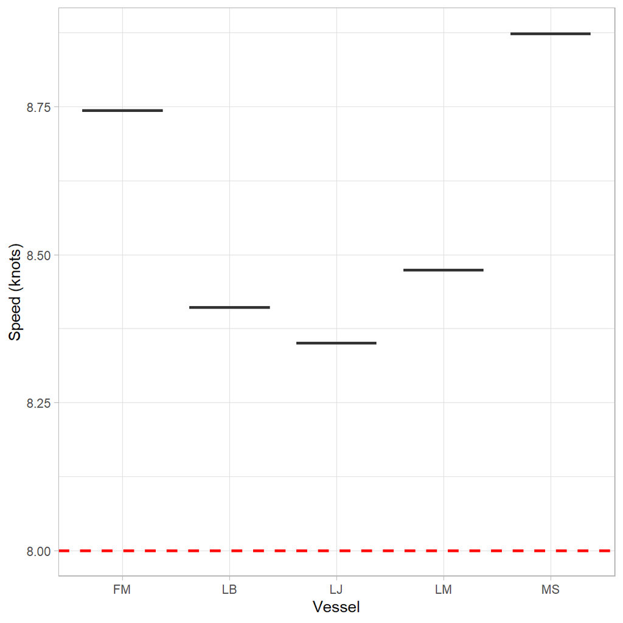

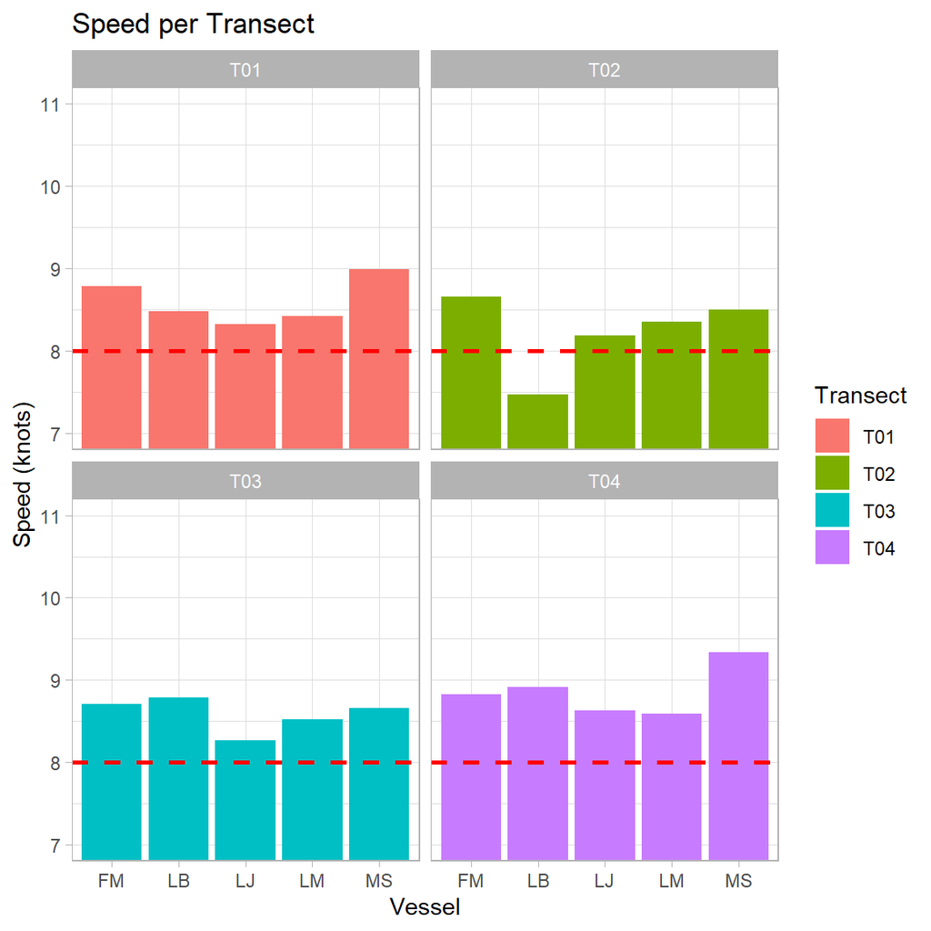

Average vessel speed was 8.57. This is above the 8 knot requirement; vessels are urged to slow down to prevent backscatter noise from interfering with the acoustic data.

The speed for each transect are rudimentary and are calculated based on distance. If a significant amount of distance is cut, the speed will appear slower.